# Qualitative Analysis of Dumbbell Exercise

### Objective

This document tries to study existing data, create model and predict quality of dumbbell exercise performed by multiple participants.

Using devices such as Jawbone Up, Nike FuelBand, and Fitbit it is now possible to collect a large amount of data about personal activity relatively inexpensively. These type of devices are part of the quantified self movement ? a group of enthusiasts who take measurements about themselves regularly to improve their health, to find patterns in their behavior, or because they are tech geeks. One thing that people regularly do is quantify how much of a particular activity they do, but they rarely quantify how well they do it.

Participants were asked to perform one set of 10 repetitions of the Unilateral Dumbbell Biceps Curl in Five different fash- ions: exactly according to the specification (Class A), throw- ing the elbows to the front (Class B), lifting the dumbbell only halfway (Class C), lowering the dumbbell only halfway (Class D) and throwing the hips to the front (Class E). Class A corresponds to the specified execution of the exercise, while the other 4 classes correspond to common mistakes. Participants were supervised by an experienced weight lifter to make sure the execution complied to the manner they were supposed to simulate. The exercises were performed by six male participants aged between 20-28 years, with little weight lifting experience. We made sure that all participants could easily simulate the mistakes in a safe and controlled manner by using a relatively light dumbbell (1.25kg).

The existing training data for this project are available here:

https://d396qusza40orc.cloudfront.net/predmachlearn/pml-training.csv

The new test data to test the model are available here:

https://d396qusza40orc.cloudfront.net/predmachlearn/pml-testing.csv

These data come from the following source. We give people from this source full credit to share the data with us.

http://groupware.les.inf.puc-rio.br/har.

### Data Processing

- Read the training and test data
- Filter the data horizontally and vertically as per the selected features
- No NAs are found in the variables
- Partition the training data
- No near zero variance variables found

```r
library(caret)
set.seed(300)
tr<-read.csv("pml-training.csv")

library(doParallel)
registerDoParallel(cores=detectCores(all.tests=TRUE))

tr<-subset(tr,new_window=="no")
tr<-subset(tr,subset=T,select=c(roll_belt,pitch_belt,yaw_belt,total_accel_belt,gyros_belt_x,gyros_belt_y,gyros_belt_z,accel_belt_x,accel_belt_y,accel_belt_z,magnet_belt_x,magnet_belt_y,magnet_belt_z,total_accel_arm,accel_arm_x,accel_arm_y,accel_arm_z,magnet_arm_x,magnet_arm_y,magnet_arm_z,roll_dumbbell,pitch_dumbbell,yaw_dumbbell,total_accel_dumbbell,gyros_dumbbell_x,gyros_dumbbell_y,gyros_dumbbell_z,accel_dumbbell_x,accel_dumbbell_y,accel_dumbbell_z,magnet_dumbbell_x,magnet_dumbbell_y,magnet_dumbbell_z,pitch_forearm,yaw_forearm,roll_forearm,gyros_forearm_x,gyros_forearm_y,gyros_forearm_z,classe))

inTr<-createDataPartition(y=tr$classe,p = .3,list=F)

tr2<-tr[inTr,]

#predictors
pred<-tr2[,-dim(tr2)[2]]
#outcomes
out<-tr2[,dim(tr2)[2]]

#are any predictors varying very little to be insignificant
nzv<-nearZeroVar(pred)
nzv
```

```
## integer(0)
```

### Training the Model

- 10-fold cross validation suits this case during the training process
- We need to select some classification model
- There can be some strong and weak predictors due to overlap because of earth’s forces

So Random Forest with bagging model suits better

```r
fitControl<-trainControl(method="cv", number=10)
rfFit<-train(x=pred,y=as.factor(out),method="rf",trControl=fitControl,prox=T,allowParallel=T)
```

### Model/Fit Analysis

```r
rfFit
```

```
## Random Forest
##
## 5768 samples
##   39 predictors
##    5 classes: 'A', 'B', 'C', 'D', 'E'
##
## No pre-processing
## Resampling: Cross-Validated (10 fold)
##
## Summary of sample sizes: 5191, 5193, 5190, 5190, 5193, 5192, ...
##
## Resampling results across tuning parameters:
##
##   mtry  Accuracy   Kappa      Accuracy SD  Kappa SD
##    2    0.9717500  0.9642515  0.007888348  0.009971717
##   20    0.9774702  0.9714976  0.007000442  0.008849739
##   39    0.9668931  0.9581073  0.009058047  0.011457422
##
## Accuracy was used to select the optimal model using  the largest value.
## The final value used for the model was mtry = 20.
```

```r
rfFit$finalMode
```

```
##
## Call:
##  randomForest(x = x, y = y, mtry = param$mtry, proximity = ..1,      allowParallel = ..2)
##                Type of random forest: classification
##                      Number of trees: 500
## No. of variables tried at each split: 20
##
##         OOB estimate of  error rate: 2.13%
## Confusion matrix:
##      A    B   C   D    E class.error
## A 1626    6  10   0    0 0.009744214
## B   25 1075  11   5    0 0.036738351
## C    0   13 977  16    0 0.028827038
## D    1    0  18 925    1 0.021164021
## E    1    2   8   6 1042 0.016052880
```

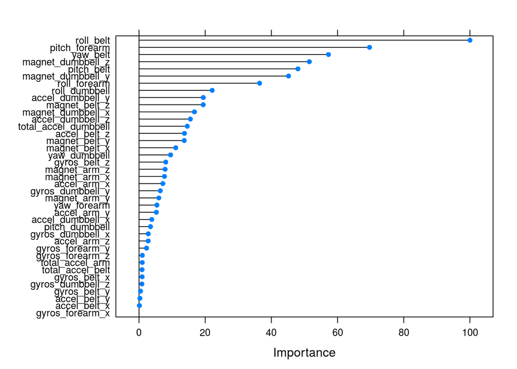

```r
plot(varImp(rfFit))
```

It confirms what we are trying to do in terms of predictors, classes, resampling, preprocessing, cross validation information, count of trees and accuracy output. The model has selected various mtry options (count of predictors selected in each split). The best, most accurate one, will be selected.

The important variables are also plotted.

The model is ready to be tested.

### Testing the Model

```r
ts2<-tr[-inTr,]
#predictors
pred2<-ts2[,-dim(ts2)[2]]
#psts3<-predict(pp,psts3)
#outcomes
out2<-ts2[,dim(ts2)[2]]
#length(osts)
res<-predict(rfFit,pred2)
confusionMatrix(res,out2)
```

```
## Confusion Matrix and Statistics
##
##           Reference
## Prediction    A    B    C    D    E
##          A 3807   58    0    0    2
##          B   12 2493   29    4    7
##          C    6   37 2310   52    6
##          D    0   14    7 2140   13
##          E    4    0    0    6 2441
##
## Overall Statistics
##
##                Accuracy : 0.9809
##                  95% CI : (0.9784, 0.9831)
##     No Information Rate : 0.2847
##     P-Value [Acc > NIR] : < 2.2e-16
##
##                   Kappa : 0.9758
##  Mcnemar's Test P-Value : NA
##
## Statistics by Class:
##
##                      Class: A Class: B Class: C Class: D Class: E
## Sensitivity            0.9943   0.9581   0.9847   0.9718   0.9887
## Specificity            0.9938   0.9952   0.9909   0.9970   0.9991
## Pos Pred Value         0.9845   0.9796   0.9581   0.9844   0.9959
## Neg Pred Value         0.9977   0.9900   0.9967   0.9945   0.9975
## Prevalence             0.2847   0.1935   0.1744   0.1637   0.1836
## Detection Rate         0.2831   0.1854   0.1718   0.1591   0.1815
## Detection Prevalence   0.2876   0.1892   0.1793   0.1617   0.1823
## Balanced Accuracy      0.9940   0.9767   0.9878   0.9844   0.9939
```

The most important parameter is accuracy. P-values indicates that we reject the null hypothesis.

Accuracy: 0.9809

It confirms our good faith in the model.